# 2 - A First Look at R

Joseph Rickert

September 28, 2015

## A Simple Regression Example

This simple regression example comes from Peter Dalgaard’s classic book: Statistics and Computing, Introductory Statistics with R (Springer 2002)

```r
library(ISwR)             # Load the ISwR package written for the book
data(package="ISwR")      # Look at the data sets that come with the package
```

The thuesen data set which comes with the ISwR package has 24 rows and two columns containing ventricular shortening velocity and blood glucose for type 1 diabetic patients. Lets load the data set into the R environment and have a look at it. Later on we will see how to read data from files and databases into R.

The data set is structured as a data frame, the most commpn data structure for doing statistical analyses in R.

```r
data(thuesen)            # loads the data
thuesen                  # prints it to the console
```

```
##    blood.glucose short.velocity
## 1           15.3           1.76
## 2           10.8           1.34
## 3            8.1           1.27
## 4           19.5           1.47
## 5            7.2           1.27
## 6            5.3           1.49
## 7            9.3           1.31
## 8           11.1           1.09
## 9            7.5           1.18
## 10          12.2           1.22
## 11           6.7           1.25
## 12           5.2           1.19
## 13          19.0           1.95
## 14          15.1           1.28
## 15           6.7           1.52
## 16           8.6             NA
## 17           4.2           1.12
## 18          10.3           1.37
## 19          12.5           1.19
## 20          16.1           1.05
## 21          13.3           1.32
## 22           4.9           1.03
## 23           8.8           1.12
## 24           9.5           1.70
```

Very useful functions for examining large data sets are:

```r
head(thuesen)            # print the first 6 lines
```

```
##   blood.glucose short.velocity
## 1          15.3           1.76
## 2          10.8           1.34
## 3           8.1           1.27
## 4          19.5           1.47
## 5           7.2           1.27
## 6           5.3           1.49
```

and

```r
tail(thuesen)            # print the last 6 lines
```

```
##    blood.glucose short.velocity
## 19          12.5           1.19
## 20          16.1           1.05
## 21          13.3           1.32
## 22           4.9           1.03
## 23           8.8           1.12
## 24           9.5           1.70
```

```r
dim(thuesen)             # look at the dimension of the data frame
```

```
## [1] 24  2
```

```r
class(thuesen)           # Find out what kind of object thuesen is
```

```
## [1] "data.frame"
```

## Basic Statistics

```r
attach(thuesen)         # Make columns of data set thuesen available as
                        # variables in the global environment
mean(blood.glucose)
```

```
## [1] 10.3
```

```r
median(blood.glucose)
```

```
## [1] 9.4
```

```r
min(blood.glucose)
```

```
## [1] 4.2
```

```r
max(blood.glucose)
```

```
## [1] 19.5
```

```r
var(blood.glucose)
```

```
## [1] 18.81391
```

```r
sd(blood.glucose)
```

```
## [1] 4.337501
```

```r
summary(blood.glucose)
```

```
##    Min. 1st Qu.  Median    Mean 3rd Qu.    Max.
##   4.200   7.075   9.400  10.300  12.700  19.500
```

```r
detach(thuesen)
```

## Vectorized Code

This next bit of code shows off a very powerful feature of the R language: how many functions are “vectorized”. The function sapply() takes the funcion class() that we just used on the data frame and applies it to all of the columns of the data frame.

```r
sapply(thuesen,class)   # Find out what kind of animals the variables are
```

```
##  blood.glucose short.velocity
##      "numeric"      "numeric"
```

```r
sapply(thuesen,summary) # Get numerical summaries of the variables
```

```
## $blood.glucose
##    Min. 1st Qu.  Median    Mean 3rd Qu.    Max.
##   4.200   7.075   9.400  10.300  12.700  19.500
##
## $short.velocity
##    Min. 1st Qu.  Median    Mean 3rd Qu.    Max.    NA's
##   1.030   1.185   1.270   1.326   1.420   1.950       1
```

## Plots in R

R has three systems for static graphics: base graphics, lattice and ggplot2. For now we will see how easy it is to produce bare bones plots with the base graphics system.

Note that you can produce a basic scatter plot either by giving the plot() function a formula or a pair of coordinates

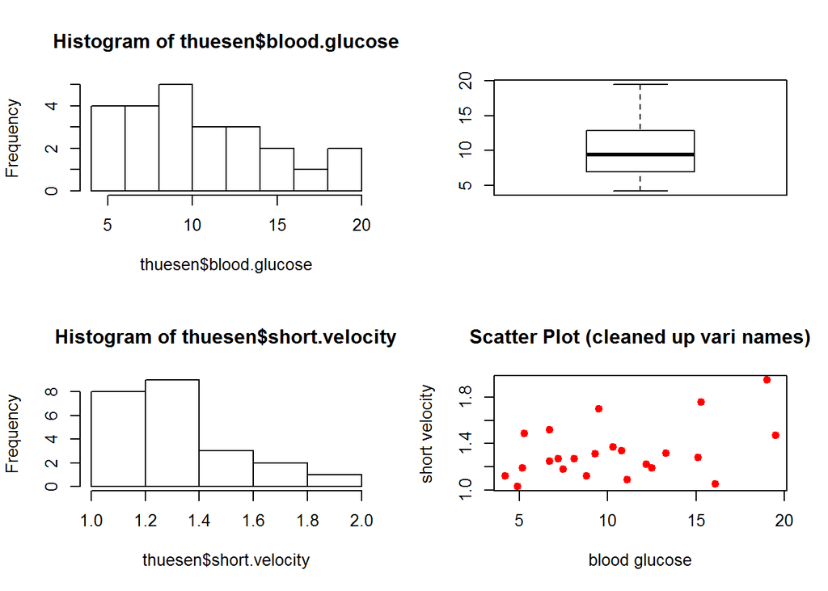

```r
#
par(mfrow=c(2,2))        # put multiple plots on a single graph
hist(thuesen$blood.glucose)
boxplot(thuesen$blood.glucose)
hist(thuesen$short.velocity)
plot(thuesen$blood.glucose,thuesen$short.velocity,   # index into the data frame
     pch = 19, col="red",
     main = "Scatter Plot (cleaned up vari names)",
     xlab = "blood glucose",
     ylab = "short velocity")
```

```r
#
```

## Linear Regression in R

Now, let’s build a simple regression model, examine the results of the model and plot the points and the regression line.

```r
model <- lm(short.velocity ~ blood.glucose, data=thuesen) # build the model
summary(model)                                            # look at results
```

```
##
## Call:
## lm(formula = short.velocity ~ blood.glucose, data = thuesen)
##
## Residuals:
##      Min       1Q   Median       3Q      Max
## -0.40141 -0.14760 -0.02202  0.03001  0.43490
##
## Coefficients:
##               Estimate Std. Error t value Pr(>|t|)
## (Intercept)    1.09781    0.11748   9.345 6.26e-09 ***
## blood.glucose  0.02196    0.01045   2.101   0.0479 *
## ---
## Signif. codes:  0 '***' 0.001 '**' 0.01 '*' 0.05 '.' 0.1 ' ' 1
##
## Residual standard error: 0.2167 on 21 degrees of freedom
##   (1 observation deleted due to missingness)
## Multiple R-squared:  0.1737, Adjusted R-squared:  0.1343
## F-statistic: 4.414 on 1 and 21 DF,  p-value: 0.0479
```

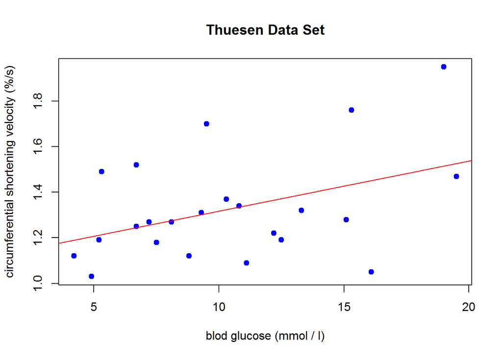

```r
plot(x = thuesen$blood.glucose,
     y = thuesen$short.velocity,
     xlab = "blod glucose (mmol / l)",
     ylab = "circumferential shortening velocity (%/s)",
     main = "Thuesen Data Set",
     col = "blue",pch=19)
abline(model,col="red")             # adds the regression line
```

Produce the standard ANOVA table for the model

```r
anova(model)
```

```
## Analysis of Variance Table
##
## Response: short.velocity
##               Df  Sum Sq  Mean Sq F value Pr(>F)
## blood.glucose  1 0.20727 0.207269   4.414 0.0479 *
## Residuals     21 0.98610 0.046957
## ---
## Signif. codes:  0 '***' 0.001 '**' 0.01 '*' 0.05 '.' 0.1 ' ' 1
```

## Regression Diagnostics

It is easy to get regression diagnostic plots. The same plot function that plots points either with a formula or with the coordinates also has a “method” for dealing with a model object.

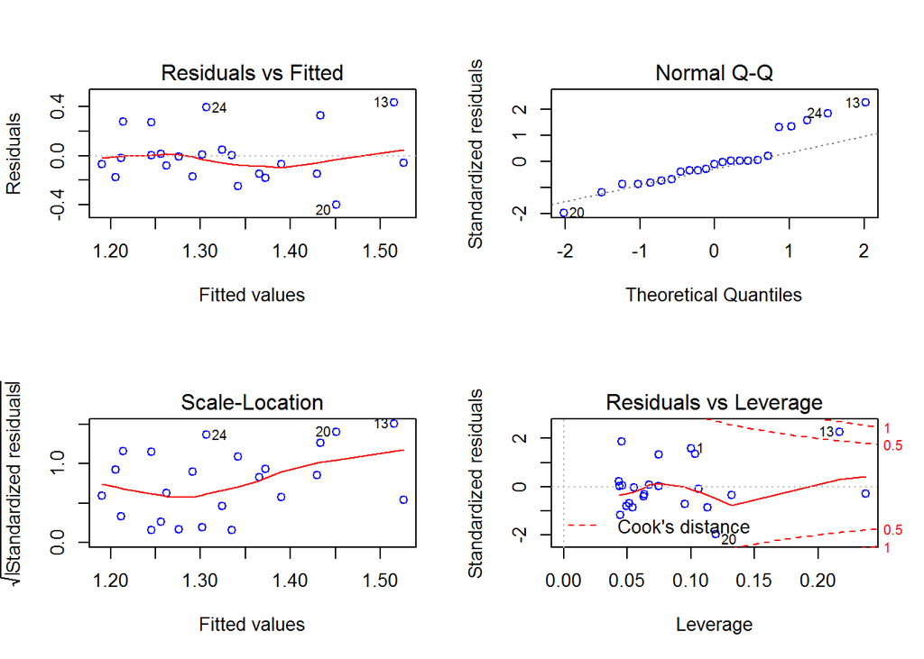

```r
par(mfrow=c(2,2))                   # Set up for multiple plots on the same figure
plot(model,col="blue")              # Look at some model diagnostics
```

## The Model Object

Finally, let’s look at the model object. R packs everything that goes with the model, the fornula, and results into the object. You can pick out what you need by indexin into the model object.

```r
str(model)
```

```
## List of 13
##  $ coefficients : Named num [1:2] 1.098 0.022
##   ..- attr(*, "names")= chr [1:2] "(Intercept)" "blood.glucose"
##  $ residuals    : Named num [1:23] 0.32616 0.00499 -0.00571 -0.05608 0.01405 ...
##   ..- attr(*, "names")= chr [1:23] "1" "2" "3" "4" ...
##  $ effects      : Named num [1:23] -6.3576 0.4553 -0.0544 -0.1324 -0.0325 ...
##   ..- attr(*, "names")= chr [1:23] "(Intercept)" "blood.glucose" "" "" ...
##  $ rank         : int 2
##  $ fitted.values: Named num [1:23] 1.43 1.34 1.28 1.53 1.26 ...
##   ..- attr(*, "names")= chr [1:23] "1" "2" "3" "4" ...
##  $ assign       : int [1:2] 0 1
##  $ qr           :List of 5
##   ..$ qr   : num [1:23, 1:2] -4.796 0.209 0.209 0.209 0.209 ...
##   .. ..- attr(*, "dimnames")=List of 2
##   .. .. ..$ : chr [1:23] "1" "2" "3" "4" ...
##   .. .. ..$ : chr [1:2] "(Intercept)" "blood.glucose"
##   .. ..- attr(*, "assign")= int [1:2] 0 1
##   ..$ qraux: num [1:2] 1.21 1.02
##   ..$ pivot: int [1:2] 1 2
##   ..$ tol  : num 1e-07
##   ..$ rank : int 2
##   ..- attr(*, "class")= chr "qr"
##  $ df.residual  : int 21
##  $ na.action    :Class 'omit'  Named int 16
##   .. ..- attr(*, "names")= chr "16"
##  $ xlevels      : Named list()
##  $ call         : language lm(formula = short.velocity ~ blood.glucose, data = thuesen)
##  $ terms        :Classes 'terms', 'formula' length 3 short.velocity ~ blood.glucose
##   .. ..- attr(*, "variables")= language list(short.velocity, blood.glucose)
##   .. ..- attr(*, "factors")= int [1:2, 1] 0 1
##   .. .. ..- attr(*, "dimnames")=List of 2
##   .. .. .. ..$ : chr [1:2] "short.velocity" "blood.glucose"
##   .. .. .. ..$ : chr "blood.glucose"
##   .. ..- attr(*, "term.labels")= chr "blood.glucose"
##   .. ..- attr(*, "order")= int 1
##   .. ..- attr(*, "intercept")= int 1
##   .. ..- attr(*, "response")= int 1
##   .. ..- attr(*, ".Environment")=<environment: R_GlobalEnv>
##   .. ..- attr(*, "predvars")= language list(short.velocity, blood.glucose)
##   .. ..- attr(*, "dataClasses")= Named chr [1:2] "numeric" "numeric"
##   .. .. ..- attr(*, "names")= chr [1:2] "short.velocity" "blood.glucose"
##  $ model        :'data.frame':   23 obs. of  2 variables:
##   ..$ short.velocity: num [1:23] 1.76 1.34 1.27 1.47 1.27 1.49 1.31 1.09 1.18 1.22 ...
##   ..$ blood.glucose : num [1:23] 15.3 10.8 8.1 19.5 7.2 5.3 9.3 11.1 7.5 12.2 ...
##   ..- attr(*, "terms")=Classes 'terms', 'formula' length 3 short.velocity ~ blood.glucose
##   .. .. ..- attr(*, "variables")= language list(short.velocity, blood.glucose)
##   .. .. ..- attr(*, "factors")= int [1:2, 1] 0 1
##   .. .. .. ..- attr(*, "dimnames")=List of 2
##   .. .. .. .. ..$ : chr [1:2] "short.velocity" "blood.glucose"
##   .. .. .. .. ..$ : chr "blood.glucose"
##   .. .. ..- attr(*, "term.labels")= chr "blood.glucose"
##   .. .. ..- attr(*, "order")= int 1
##   .. .. ..- attr(*, "intercept")= int 1
##   .. .. ..- attr(*, "response")= int 1
##   .. .. ..- attr(*, ".Environment")=<environment: R_GlobalEnv>
##   .. .. ..- attr(*, "predvars")= language list(short.velocity, blood.glucose)
##   .. .. ..- attr(*, "dataClasses")= Named chr [1:2] "numeric" "numeric"
##   .. .. .. ..- attr(*, "names")= chr [1:2] "short.velocity" "blood.glucose"
##   ..- attr(*, "na.action")=Class 'omit'  Named int 16
##   .. .. ..- attr(*, "names")= chr "16"
##  - attr(*, "class")= chr "lm"
```

Index into the model object and pull out the coefficients

```r
model$coefficients
```

```
##   (Intercept) blood.glucose
##    1.09781488    0.02196252
```

```r
beta_0 <- model$coefficients[1]
beta_0
```

```
## (Intercept)
##    1.097815
```

```r
beta_1 <- model$coefficients[2]
beta_1
```

```
## blood.glucose
##    0.02196252
```